# Klamath Basin Bird Data

Maddee Wiggins (FlowWest)

2026-09-01

## Define Geographies

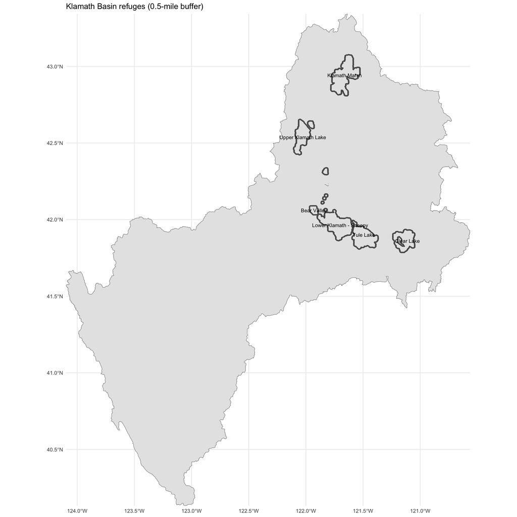

## Build Dataset

We compiled eBird observations from 2015–2025 for the Klamath Basin watershed. These data were merged with BIRDBASE, which provides information on each species’ primary habitat and diet. Additional information on waterbirds was drawn from Donnelly et al. (2022). Further details on each dataset are provided in the following tabs.

Below, we explore potential groupings of bird species based on these combined sources in the Bird Groupings section

### eBird

##### Data Source

Data were obtained from the [eBird Basic Dataset (EBD)](https://science.ebird.org/en/use-ebird-data/download-ebird-data-products) via custom downloads. The following counties intersecting the Klamath Basin were included:

- California: Del Norte (CA-015), Humboldt (CA-023), Modoc (CA-049), Siskiyou (CA-093), Trinity (CA-105)
- Oregon: Jackson (OR-029), Lake (OR-037), Klamath (OR-035)

Each download included:

- Observation data (.txt)
- Sampling event metadata (_sampling.txt)
- Data filtered using the [auk](https://cornelllabofornithology.github.io/auk/) R package

##### Spatial Filtering

All eBird data was clipped to the `rivermile::klamath_refuges` boundaries, each buffered by 0.5 miles.

#### Limitations and Biases

While eBird provides a vast and valuable source of bird observation data, several **limitations and biases** must be considered when interpreting species richness in the Klamath Basin:

#### Spatial and Temporal Bias

- **Uneven geographic coverage**: Observations are concentrated near roads, towns, protected areas, or known birding hotspots rather than being evenly distributed across the basin.
- **Accessibility**: Remote, rugged, or private lands are under-surveyed due to difficulty of access.
- **Temporal bias**: Observations are skewed toward **weekends**, holidays, and the **month of May**, when birding activity typically increases due to spring migration and favorable weather.

#### Observer Skill and Experience

- Bird detection and identification are highly dependent on the skill level of the observer:
- **Novice observers** may miss or misidentify species, especially cryptic or similar-looking birds.
- **Experienced birders** may detect more species per checklist, leading to inflated richness in certain areas.

#### Personal Preference and Targeting

- Observer decisions introduce subjectivity:
- Birders may intentionally seek out **rare** or **charismatic** species.
- Areas near homes, parks, or favorite hotspots may be surveyed more often.
- “Chasing” behavior (targeting recent rare sightings) may artificially inflate species counts at specific locations.

##### Checklist Effort and Metadata Variability

- Despite quality filters (complete checklists, effort constraints), variability remains in:
- **Number of observers**
- **Start time of surveys**
- **Use of playback, feeders, or attractants**

These factors influence the likelihood of species detection.

#### Presence-Only Limitations

- eBird is a **presence-only** dataset.
- A species not reported on a checklist does **not imply absence**—it may simply have gone undetected.
- Species with low detectability or limited seasonal presence may be underrepresented.

[This markdown follows ebird best practices](https://ebird.github.io/ebird-best-practices/)

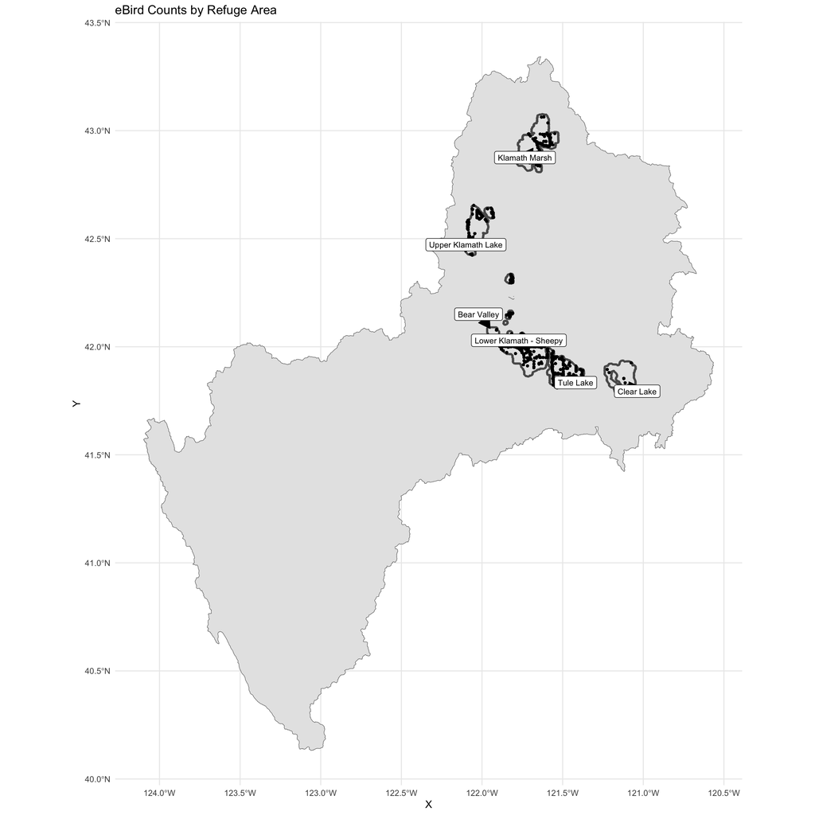

#### Temporal Trends in Species Richness

This plot shows the total number of unique species recorded per year. Peaks may correspond to years with higher survey effort, observer participation, or migration events.

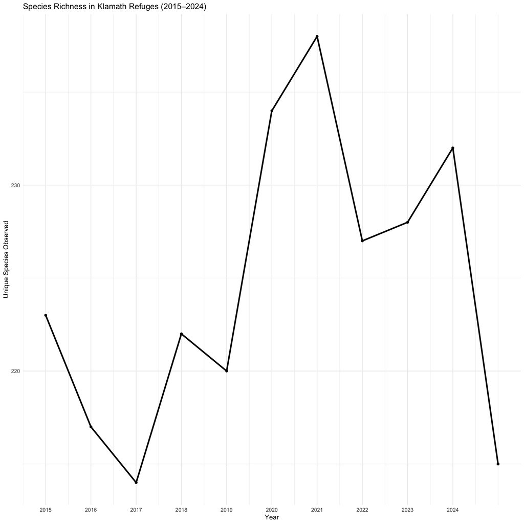

#### Top 10 Most Frequently Observed Species

These species are the most commonly reported across all checklists, often due to being common, conspicuous, or resident year-round.

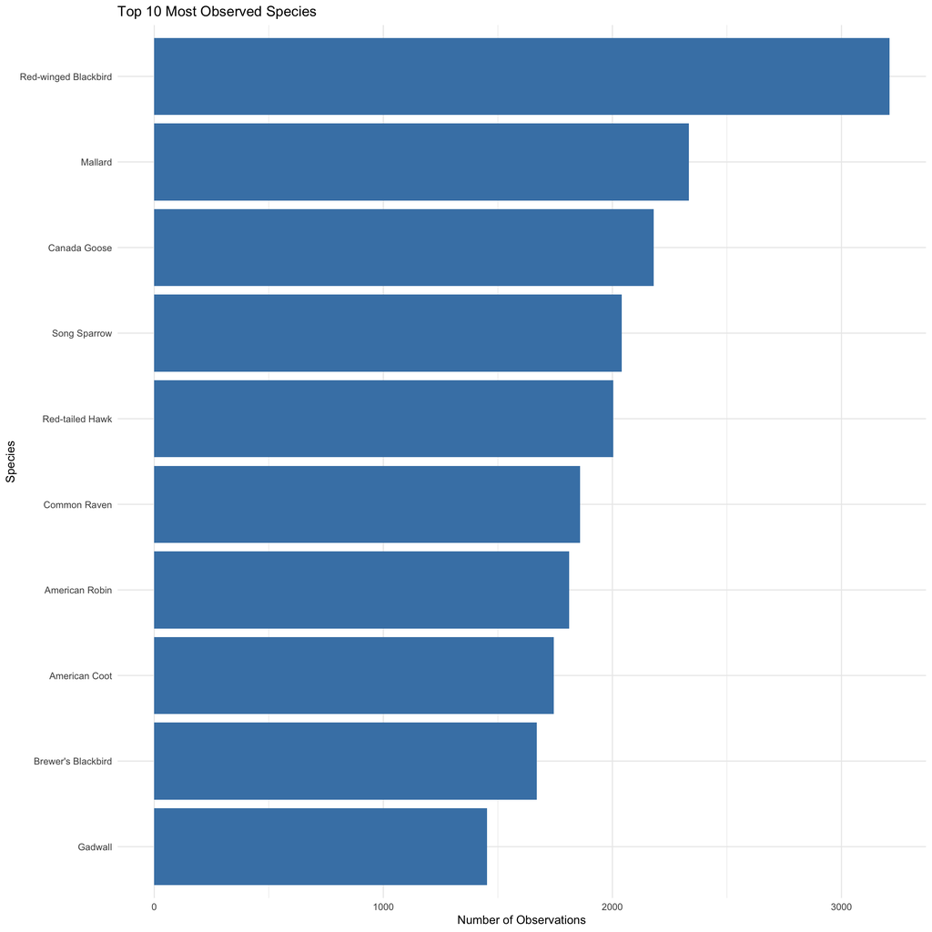

Seasonal Bird Species Richness

Spring is the season with more observations from bird watchers, and winter is the lowest. This is not surprising due to the frequency of when people spend time outside during these seasons.

- Note that this can be misinterpreted due to the temporal variability of bird watchers

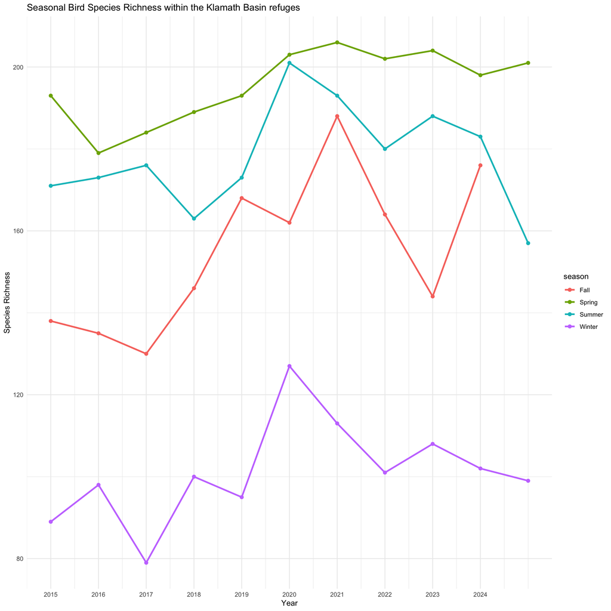

Checklist Species Richness in Klamath Basin

species_observed value in your code represents the number of unique species recorded in each individual eBird checklist

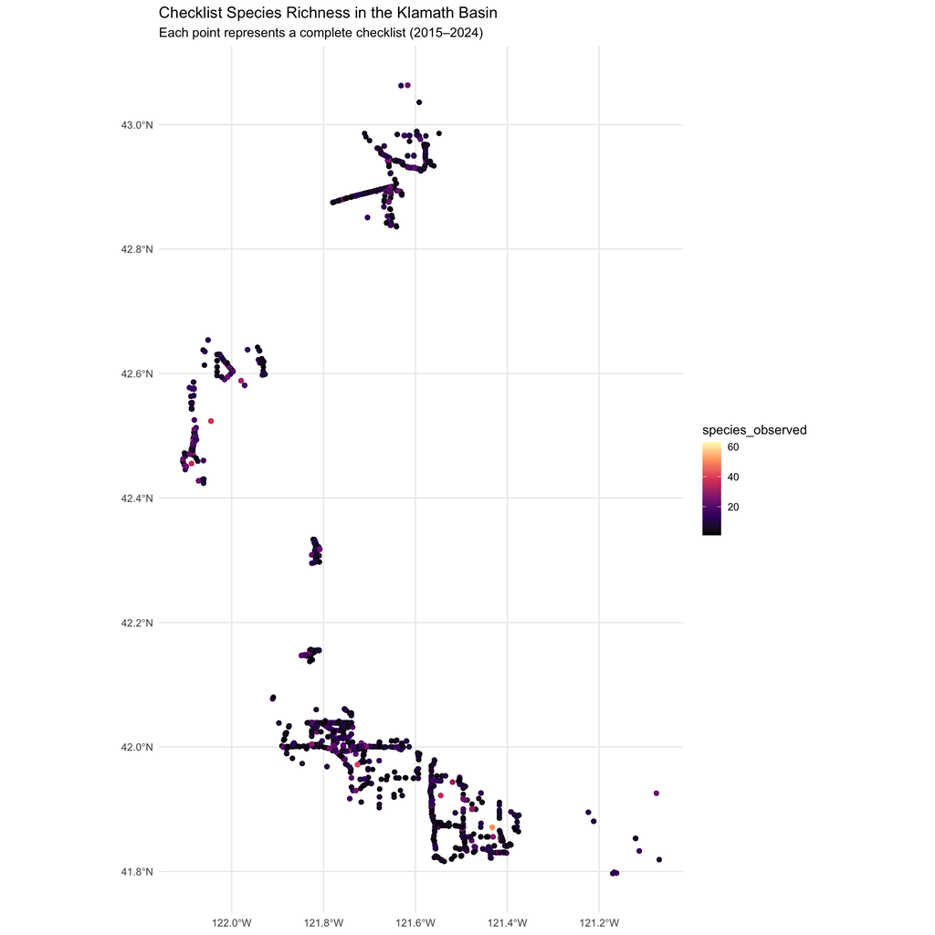

#### Monthly Richness Trends

Richness peaks in spring and early summer, again corresponding to migration and peak observation periods

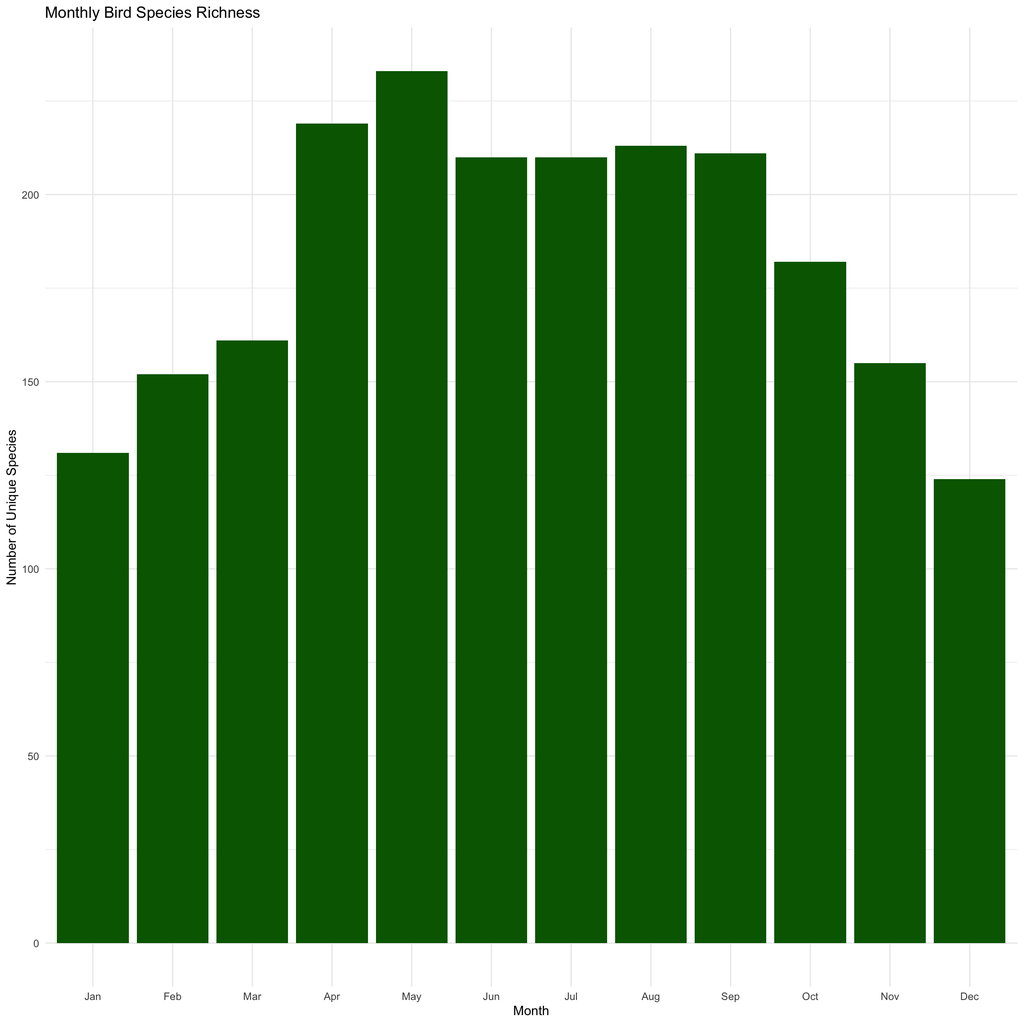

### BIRDBASE

BIRDBASE [^1] provides a thorough, literature based review of all bird species and includes habitat and foraging information that can be used to assign birds to guilds.

The `primary habitat` and `primary diet` values were used but it’s worth noting that BIRDBASE provides information on how each bird species fits into each type. This could help if a more involved analysis is requested.

```
## Rows: 11,589
## Columns: 97
## $ ioc_15_1                                     <dbl> 1, 6, 8, 14, 18, 21, 23, …
## $ english_name_bird_life_ioc_clements_avi_list <chr> "Common Ostrich", "Somali…
## $ latin_bird_life_ioc_clements_avi_list        <chr> "Struthio camelus", "Stru…
## $ hbw_bird_life_international_v9_1             <chr> "Struthio camelus", "Stru…
## $ ioc_world_bird_list_v15_1                    <chr> "Struthio camelus", "Stru…
## $ e_bird_clements_v2024b                       <chr> "Struthio camelus", "Stru…
## $ avi_list_v1_2025                             <chr> "Struthio camelus", "Stru…
## $ order                                        <chr> "Struthioniformes", "Stru…
## $ family_ioc_15_1                              <chr> "Struthionidae", "Struthi…
## $ family_clements_v2024b                       <chr> "Struthionidae", "Struthi…
## $ family_hbw_bird_life_v9_1_2024               <chr> "Struthionidae", "Struthi…
## $ family_avi_list_v1_2025                      <chr> "Struthionidae", "Struthi…
## $ genus                                        <chr> "Struthio", "Struthio", "…
```

[output cut: 84 more lines]

Merge ebird with BIRDBASE to get guild information:

The two datasets can easily be merged by the `scientific name`. The final dataset was heavily truncated to include on the data that is needed for this analysis.

### Waterbirds Definitions

This table provides definitions for the `waterbird niche` which we will add as a potential grouping characteristic to the final dataset. Based off of table 2 of Donnelly et al., 2022[^2].

| waterbird_niche | common_name |
| --- | --- |
| Shorebirds | American Avocet |
| Shorebirds | Black-necked Stilt |
| Shorebirds | Dunlin |
| Shorebirds | Greater Yellowlegs |
| Shorebirds | Lesser Yellowlegs |
| Shorebirds | Long-billed Dowitcher |
| Shorebirds | Marbled Godwit |
| Shorebirds | Western Sandpiper |
| Shorebirds | Willet |
| Shorebirds | Wilson’s Phalarope |
| Shorebirds | Wilson’s Snipe |
| Shorebirds | Whimbrel |
| Dabbling ducks | American Wigeon |
| Dabbling ducks | Cinnamon Teal |
| Dabbling ducks | Gadwall |
| Dabbling ducks | Green-winged Teal |
| Dabbling ducks | Mallard |
| Dabbling ducks | Northern Pintail |
| Dabbling ducks | Northern Shoveler |
| Diving ducks | Barrow’s Goldeneye |
| Diving ducks | Common Goldeneye |
| Diving ducks | Bufflehead |
| Diving ducks | Canvasback |
| Diving ducks | Greater Scaup |
| Diving ducks | Lesser Scaup |
| Diving ducks | Redhead |
| Diving ducks | Ring-necked Duck |
| Diving ducks | Ruddy Duck |
| Other waterbirds | American Bittern |
| Other waterbirds | American Coot |
| Other waterbirds | Black Tern |
| Other waterbirds | Eared Grebe |
| Other waterbirds | Least Bittern |
| Other waterbirds | Western Grebe |
| Other waterbirds | White-faced Ibis |

```
## Rows: 92,329
## Columns: 13
## $ common_name       <chr> "Red-winged Blackbird", "Mallard", "Greater White-fr…
## $ scientific_name   <chr> "Agelaius phoeniceus", "Anas platyrhynchos", "Anser …
## $ observation_count <chr> "25", "2", "75", "1", "1", "1", "2", "1", "11", "1",…
## $ latitude          <dbl> 41.871, 41.871, 41.871, 41.871, 41.871, 41.871, 41.8…
## $ longitude         <dbl> -121.4326, -121.4326, -121.4326, -121.4326, -121.432…
## $ observation_date  <date> 2023-04-29, 2023-04-29, 2023-04-29, 2023-04-29, 202…
## $ area              <chr> "Tule Lake", "Tule Lake", "Tule Lake", "Tule Lake", …
## $ primary_diet      <chr> "Seed", "Omnivore", "Seed", "Omnivore", "Vertebrate"…
## $ primary_habitat   <chr> "Wetland", "Wetland", "Grassland", "Wetland", "Grass…
## $ species           <chr> "phoeniceus", "platyrhynchos", "albifrons", "canaden…
## $ genus             <chr> "Agelaius", "Anas", "Anser", "Grus", "Aquila", "Arde…
## $ order             <chr> "Passeriformes", "Anseriformes", "Anseriformes", "Gr…
## $ waterbird_niche   <chr> NA, "Dabbling ducks", NA, NA, NA, NA, NA, NA, NA, NA…
```

### Piscivorous waterbirds counts

Piscivorous waterbirds were surveyed by Real Time Research and the USGS throughout the Klamath Basin between 2009 and 2024. In addition, the USFWS conducted comparable surveys in the same region from 1952 to 1956, providing a valuable historical baseline for evaluating long-term temporal trends in these species.

**Methods**

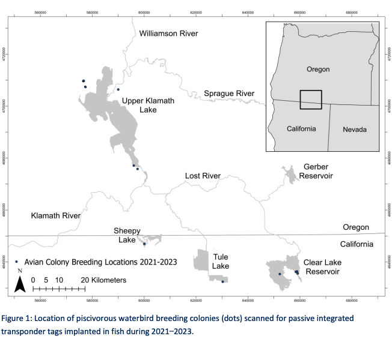

**Definitions**

- Herons = Great Blue Herons, Great Egrets, and Black-crowned Night
- Gulls = California and Ring-billed gulls

**Sources:**

RTR/USGS: 2009 - 2024

- 2009 - 2020: Table S.1 of Evans et al., 2022[^3]
- 2021-2023: Table 1 of Banet et al., 2024[^4] - 2024: Table 1 of Banet et al., 2025[^5]

Clear Lake: 1952 - 1956

- USFWS 1957 Clear Lake Refuge Report; table 8

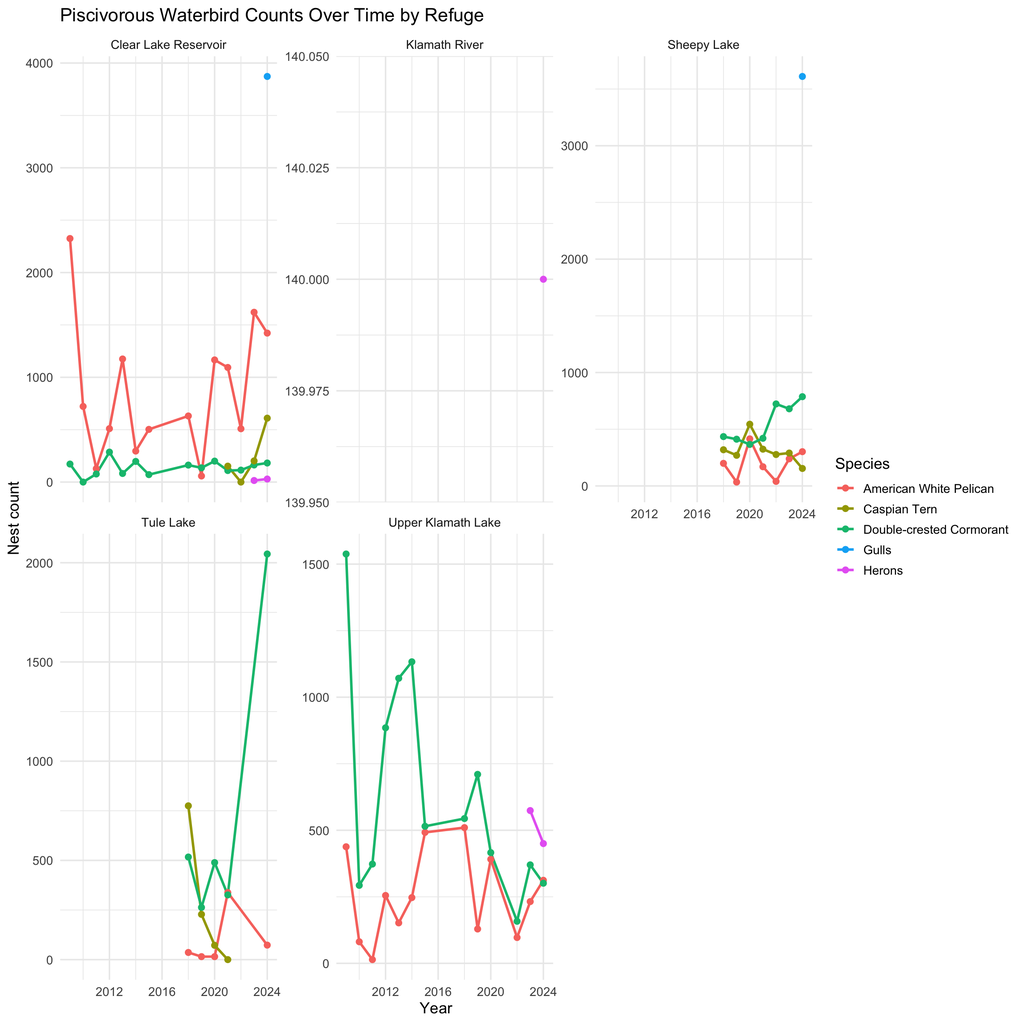

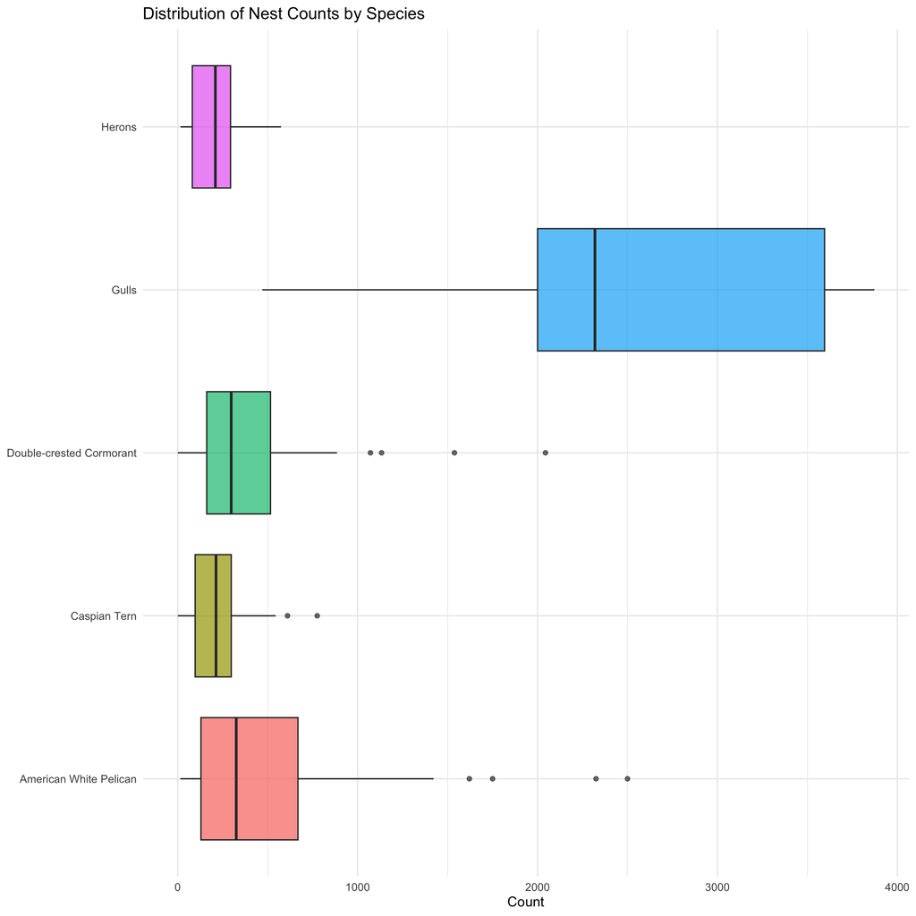

##### Compare RTR/USGS data to eBird

Aggregate piscivorous birds from eBird

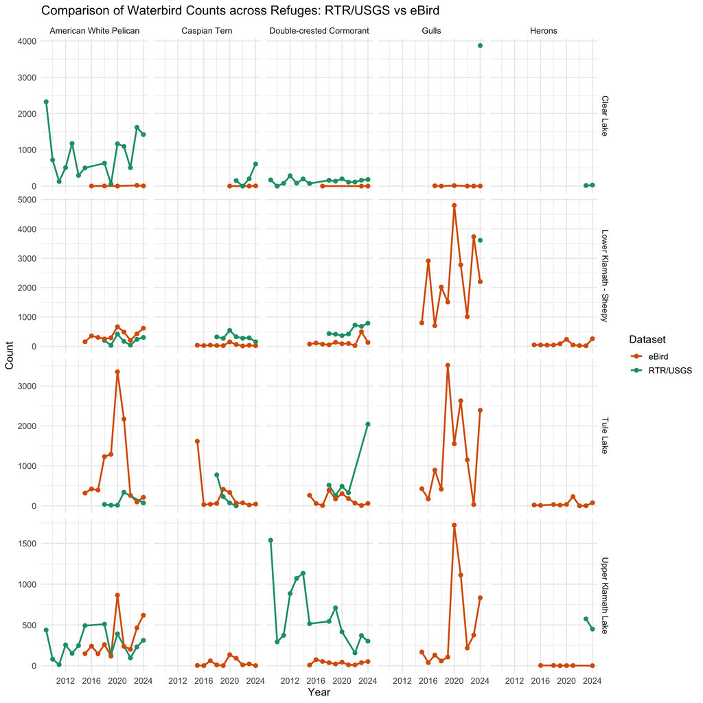

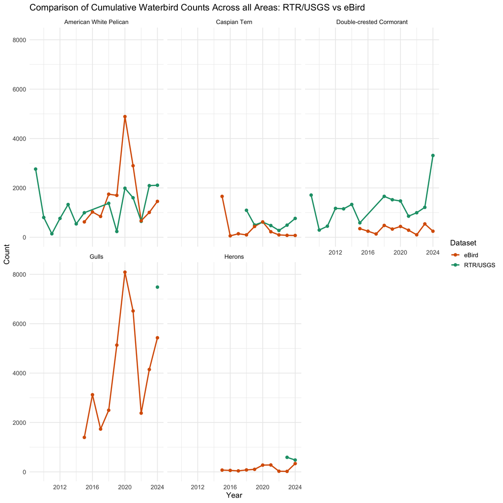

#### Compare Clear Lake 1950s data to present trends

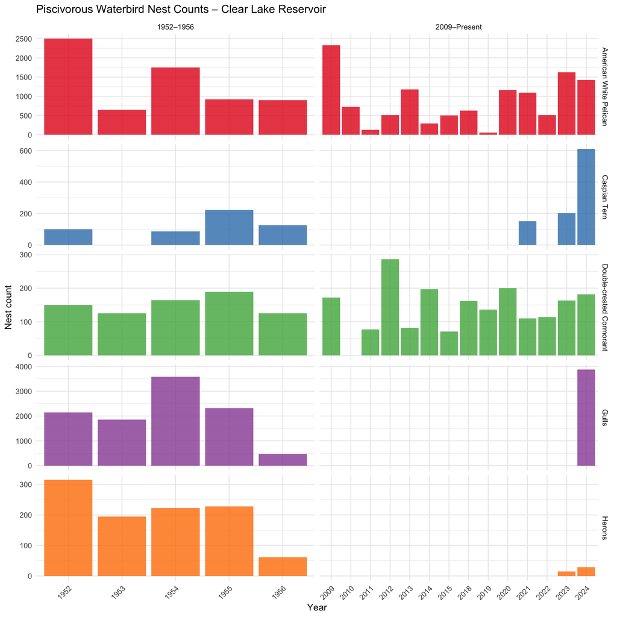

### Intermountain Shorebirds

https://www.imwss.org/

**Source** - Table 1: https://static1.squarespace.com/static/66b5066527e47020d0e0b7b0/t/673d0bf4ca1419202f3e9a2e/1732054007209/Intermountain+West+Shorebirds+-+Preliminary+Data+Summary+-+November+2024+Updated.pdf

## Potential Bird Groupings

### Waterbirds

Grouping birds identified as part of the waterbird guild - including shorebirds, diving ducks, dabbling ducks, and other waterbirds. I’ve included primary habitat as well because the waterbirds are associated with multiple.

```
## Rows: 1,505
## Columns: 6
## Groups: waterbird_niche, primary_habitat, year, month [579]
## $ waterbird_niche <chr> "Dabbling ducks", "Dabbling ducks", "Dabbling ducks", …
## $ primary_habitat <chr> "Wetland", "Wetland", "Wetland", "Wetland", "Wetland",…
## $ year            <dbl> 2015, 2015, 2015, 2015, 2015, 2015, 2015, 2015, 2015, …
## $ month           <dbl> 1, 2, 2, 3, 3, 3, 4, 4, 4, 4, 5, 5, 5, 5, 6, 6, 6, 7, …
## $ area            <chr> "Lower Klamath - Sheepy", "Lower Klamath - Sheepy", "U…
## $ n_species       <int> 2, 7, 2, 5, 7, 7, 6, 7, 7, 1, 5, 7, 4, 1, 5, 5, 4, 2, …
```

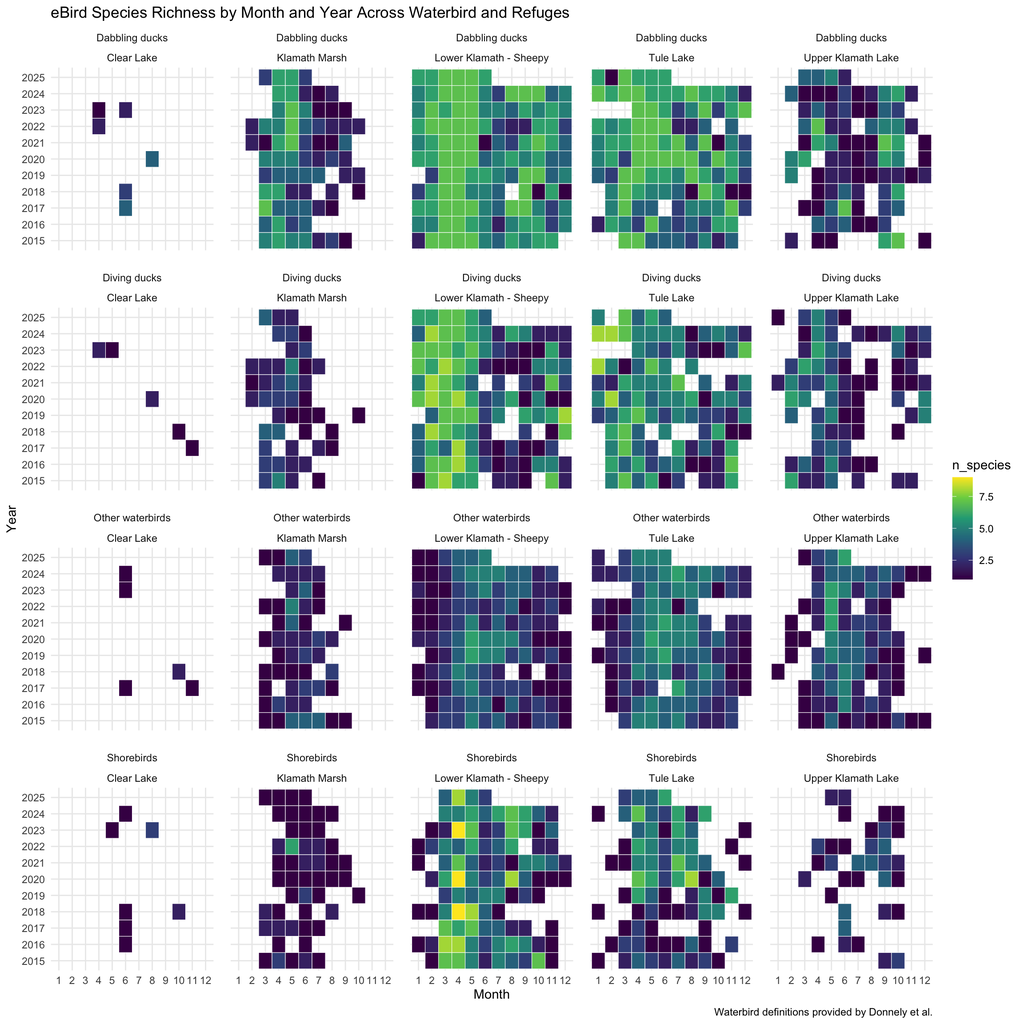

### Habitat

Grouping the Klamath bird species by the primary habitat type. Habitat types include: Wetland, Grassland, Woodland, Shrub, Savanna, Artificial, Coastal, Forest, Plains, Rocky, Riparian. The number of species across months and years are grouped by each habitat type to create the `habitat` dataset.

```
## Rows: 4,160
## Columns: 5
## $ primary_habitat <chr> "Artificial", "Artificial", "Artificial", "Artificial"…
## $ year            <dbl> 2015, 2015, 2015, 2015, 2015, 2015, 2015, 2015, 2015, …
## $ month           <dbl> 1, 1, 2, 3, 3, 3, 4, 4, 4, 4, 5, 5, 5, 5, 6, 6, 6, 6, …
## $ area            <chr> "Lower Klamath - Sheepy", "Tule Lake", "Lower Klamath …
## $ n_species       <int> 2, 2, 2, 1, 4, 4, 2, 4, 4, 2, 2, 3, 4, 1, 2, 1, 1, 2, …
```

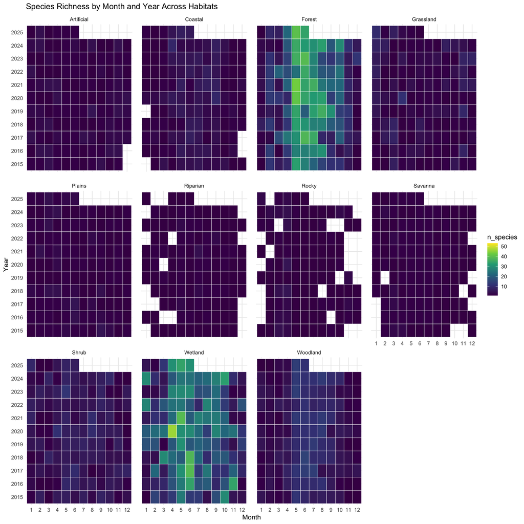

### Foraging

Grouping the Klamath bird species by the primary diet type. Diet types include: Seed, Omnivore, Vertebrate, Fish, Plant, Invertebrate, Scavenger, Carnivore, Herbivore, Nectar, Fruit. The number of species across months and years are grouped by each diet type to create the `foraging` dataset.

```
## Rows: 3,820
## Columns: 5
## $ primary_diet <chr> "Carnivore", "Carnivore", "Carnivore", "Carnivore", "Carn…
## $ year         <dbl> 2015, 2015, 2015, 2015, 2015, 2015, 2015, 2015, 2015, 201…
## $ month        <dbl> 1, 1, 2, 3, 3, 3, 4, 4, 4, 4, 5, 5, 5, 5, 6, 6, 6, 6, 7, …
## $ area         <chr> "Klamath Marsh", "Lower Klamath - Sheepy", "Lower Klamath…
## $ n_species    <int> 1, 2, 3, 2, 5, 4, 2, 5, 6, 2, 4, 7, 4, 4, 4, 3, 4, 2, 4, …
```

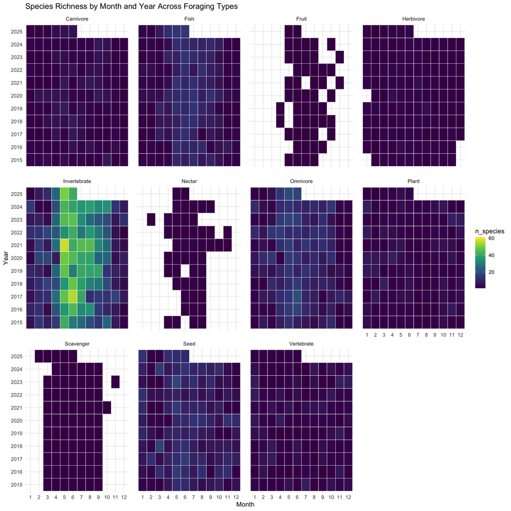

### Potential groupings based on diet and habitat

Bird species were grouped based on a combination of primary diet and primary habitat. Diet × habitat guilds were defined for each observation by pairing the species’ primary diet category with its primary habitat category. Species richness was summarized by grouping across months and years, and groupings were ranked by total species richness.

There are 56 guilds. The top 10 are:

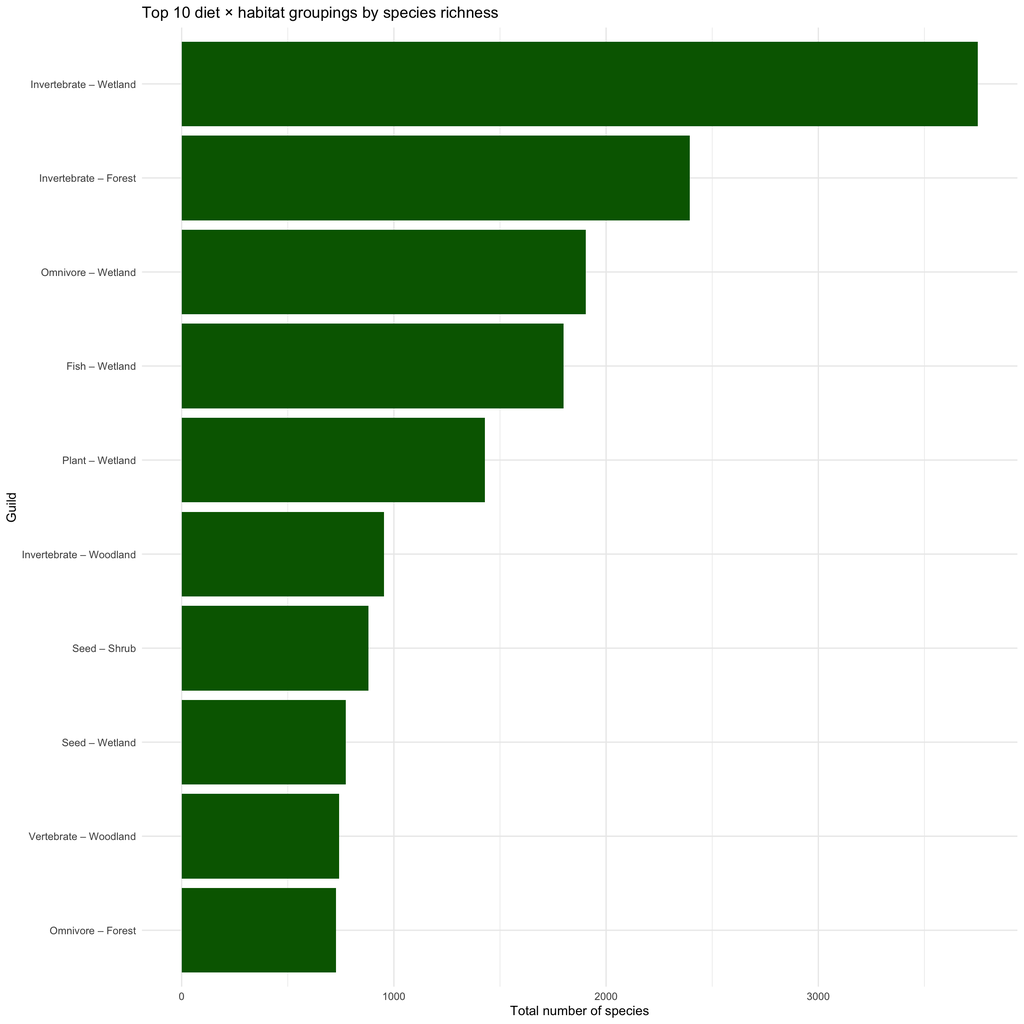

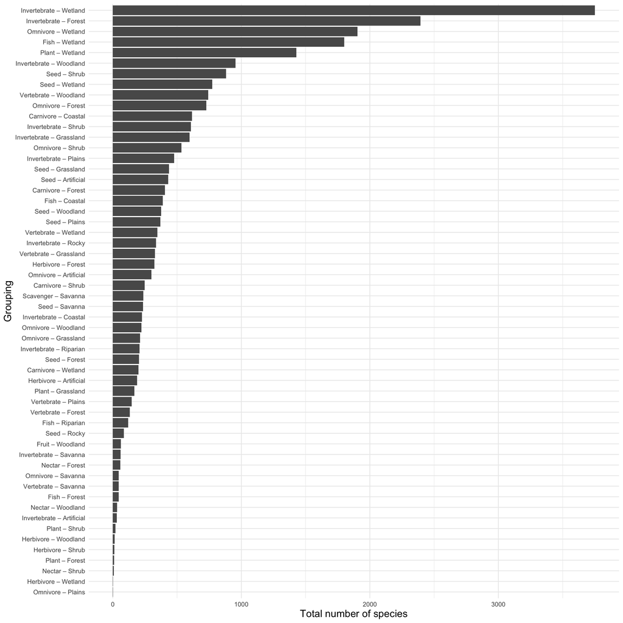

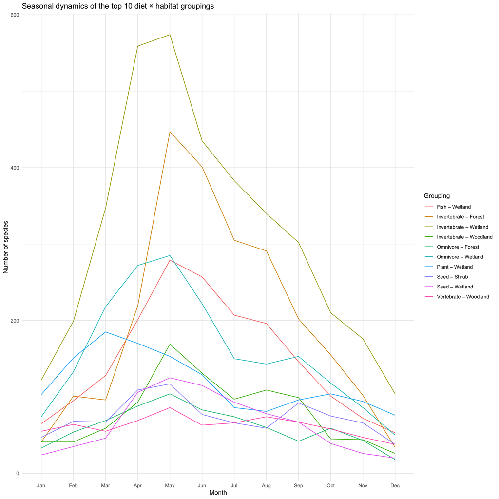

## Final *draft* datasets:

Two datasets are produced:

1. `klamath_ebird` - Bird species (source: eBird) by primary habitat, diet. Also included is the waterbird niche, which can be used when applicable. Data is provided for observed species from 2015 to 2025. Dataset is clipped to each Klamath Basin refuge boundary.

Data can be accessed as `klamathWildlifeData::klamath_ebird`

**Data Dictionary**

| Column | Definition |
| --- | --- |
| common_name | Bird species |
| observation_count | Number of species counted in observation |
| latitude | Latitude of observation |
| longitude | Longitude of observation |
| observation_date | Date of bird observation |
| area | Corresponding refuge area; this column aligns with DSWE and `piscivorous_waterbirds` |
| primary_habitat | Species primary habitat; used as a grouping variable (source: BIRDBASE) |
| primary_diet | Species primary diet; used as a grouping variable (source: BIRDBASE) |
| waterbird_niche | Waterbird guild (source: Donnelly et al., 2022) |

```
## Rows: 92,329
## Columns: 9
## $ common_name       <chr> "Red-winged Blackbird", "Mallard", "Greater White-fr…
## $ observation_count <dbl> 25, 2, 75, 1, 1, 1, 2, 1, 11, 1, 3, 1, 1, 1, 2, 8, 1…
## $ latitude          <dbl> 41.871, 41.871, 41.871, 41.871, 41.871, 41.871, 41.8…
## $ longitude         <dbl> -121.4326, -121.4326, -121.4326, -121.4326, -121.432…
## $ observation_date  <date> 2023-04-29, 2023-04-29, 2023-04-29, 2023-04-29, 202…
## $ area              <chr> "Tule Lake", "Tule Lake", "Tule Lake", "Tule Lake", …
## $ primary_habitat   <chr> "Wetland", "Wetland", "Grassland", "Wetland", "Grass…
## $ primary_diet      <chr> "Seed", "Omnivore", "Seed", "Omnivore", "Vertebrate"…
## $ waterbird_niche   <chr> NA, "Dabbling ducks", NA, NA, NA, NA, NA, NA, NA, NA…
```

Data can be accessed as `klamathWildlifeData::piscivorous_waterbirds`

**Data Dictionary**

| Column | Definition |
| --- | --- |
| nesting_location | Name of nesting location provided in original dataset/documentation |
| common_name | Bird species (note that `Gulls` = California and Ring-billed gulls and `Herons` = Great Blue Herons, Great Egrets, and Black-crowned Night |
| year | Year data was collected |
| count | Number of nests |
| source | Source of data |
| area | Corresponding refuge area; this column aligns with DSWE and `klamath_ebird` |

```
## Rows: 110
## Columns: 6
## $ nesting_location <chr> "Upper Klamath Lake", "Upper Klamath Lake", "Upper Kl…
## $ common_name      <chr> "American White Pelican", "Double-crested Cormorant",…
## $ year             <dbl> 2009, 2009, 2010, 2010, 2011, 2011, 2012, 2012, 2013,…
## $ count            <dbl> 438, 1538, 81, 293, 14, 373, 255, 885, 152, 1071, 247…
## $ source           <chr> "Table S.1 of Evans et al., 2022", "Table S.1 of Evan…
## $ area             <chr> "Upper Klamath Lake", "Upper Klamath Lake", "Upper Kl…
```

## Multispecies Subgroup Birds

Three species are of interest to the multispecies subgroup: White-faced Ibis, Eared Grebe, and Cinnamon Teal. This section asks how often each is seen and where.

### How often are they seen?

Two caveats shape how “how often” is measured here. First, `observation_count` is `NA` wherever the observer entered eBird’s `X` (present but not counted), so summing counts silently drops those records. Second, flock sizes for these species span single birds to several thousand, so a handful of large flocks would dominate any total. The number of detections (records, i.e. species × checklist) is therefore used as the frequency measure, with flock size reported separately.

Detection frequency and flock size, 2015-2025

| Species | Detections | % of all records | % uncounted (X) | Months present | Peak month | Median flock | Max flock |
| --- | --- | --- | --- | --- | --- | --- | --- |
| Cinnamon Teal | 971 | 1.05 | 6.7 | 12 | May | 4 | 600 |
| White-faced Ibis | 912 | 0.99 | 4.6 | 9 | May | 10 | 6500 |
| Eared Grebe | 511 | 0.55 | 9.8 | 12 | May | 5 | 1600 |

All three are seen regularly rather than rarely: together they account for roughly 2.6% of all eBird records in the refuges. Cinnamon Teal is the most frequently detected, followed closely by White-faced Ibis, with Eared Grebe detected about half as often. Median flock sizes are small (4-10 birds), but the maxima are two to three orders of magnitude larger — a single White-faced Ibis record of 6,500 birds — so these species are typically encountered in small numbers punctuated by occasional large aggregations.

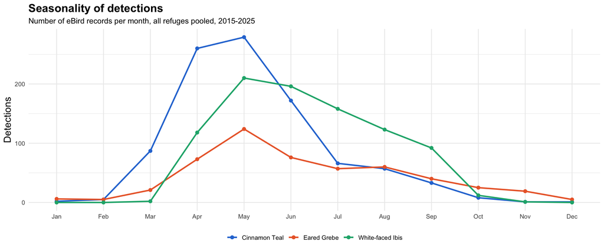

The three species have distinctly different seasonal profiles:

- **White-faced Ibis** is a strict warm-season migrant: zero records in December, January, or February across all eleven years. Birds arrive in March, peak in May-June, and linger through fall.
- **Cinnamon Teal** shows the sharpest, earliest peak — a steep rise in March and a April-May maximum consistent with spring migration and breeding — then declines through summer and is effectively absent in winter.
- **Eared Grebe** has much the flattest profile. It also peaks in May, but holds a long summer-fall plateau (Jul-Sep stays near 40-60 records, where Cinnamon Teal has already fallen to 33 by September) and is still being recorded in October and November. Both it and Cinnamon Teal are technically recorded in all twelve months, but only at a trickle of 1-6 records per month in midwinter.

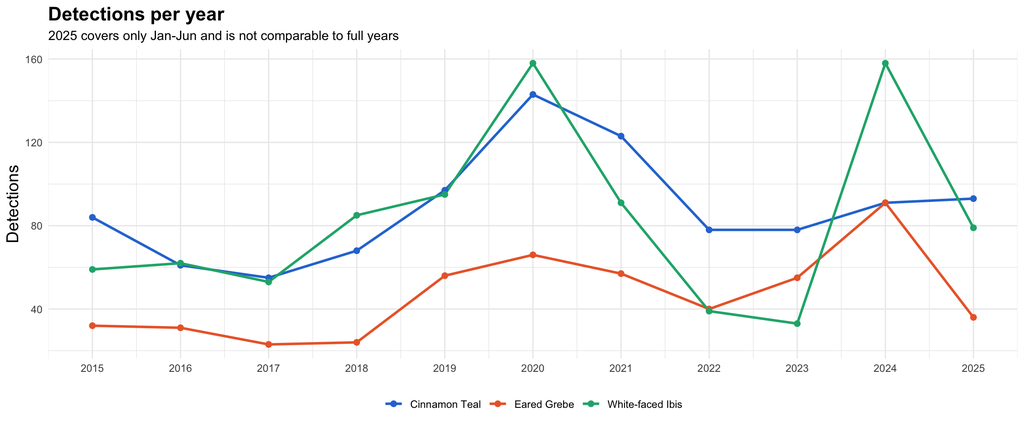

White-faced Ibis detections dropped sharply in 2022-2023 (39 and 33 records, down from 158 in 2020) and rebounded to 158 in 2024; Eared Grebe also peaked in 2024. Because eBird effort itself grew over this period, these swings should be read as changes in reported frequency rather than confirmed population change. Note that 2025 data end 30 June, so the final point reflects a half year.

### Where are they commonly seen?

Refuges differ in survey effort by nearly three orders of magnitude (Bear Valley has 48 records; Lower Klamath - Sheepy has 30,398), so detections are expressed below as a share of all eBird records within each refuge. Bear Valley and Clear Lake are excluded from this comparison: with 48 and 212 total records they cannot support a rate estimate, though it is worth noting none of the three species has ever been recorded at Bear Valley.

[figure not shown]

Effort-normalizing changes the picture in a way raw totals hide:

- **Tule Lake** is the strongest area for White-faced Ibis (1.8% of its records) and Eared Grebe (1.1%).
- **Lower Klamath - Sheepy** has the highest Cinnamon Teal rate (1.5%) and the most Cinnamon Teal detections outright (446). For the other two species it trails Tule Lake despite being the more heavily surveyed refuge — 214 Eared Grebe records against Tule Lake’s 267, and 385 ibis against 425.
- **Klamath Marsh** is the informative negative result. It is heavily surveyed (17,489 records — comparable to Tule Lake) yet yields only **four** Eared Grebe records, a rate of 0.02%, roughly 50× lower than Tule Lake. White-faced Ibis is similarly scarce there (0.17%).
- **Upper Klamath Lake** is well surveyed but consistently low for all three (0.1-0.4%).

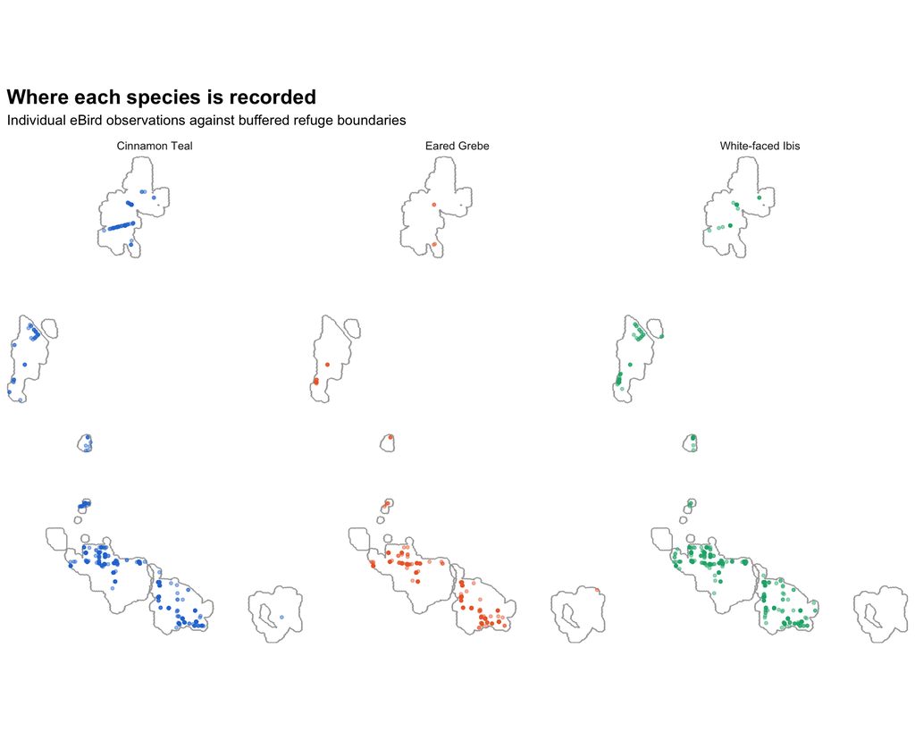

Spatially, all three cluster in the southern refuge complex (Lower Klamath and Tule Lake), which together hold the large open shallow-water and emergent-marsh habitat these species use. Cinnamon Teal is the most widely distributed of the three, with a meaningful presence at Klamath Marsh, while Eared Grebe records are almost entirely confined to Lower Klamath and Tule Lake.

As with everything drawn from eBird here, these are presence-only, effort-confounded data: a low detection rate means the species was not reported, which is not the same as absence.

[^1]: Şekercioğlu, Çağan H; Kittelberger, Kyle D.; Mota, Flávia; Buxton, Amy N.; Orton, Nikolas; DeNiro, Adara; et al. (2025). BIRDBASE: A Global Database of Avian Biogeography, Conservation, Ecology and Life History Traits. figshare. Dataset. https://doi.org/10.6084/m9.figshare.27051040.v1
[^2]: Donnelly, J. P., Moore, J. N., Casazza, M. L., & Coons, S. P. (2022). Functional wetland loss drives emerging risks to waterbird migration networks. *Frontiers in Ecology and Evolution, 10*, 844278. https://doi.org/10.3389/fevo.2022.844278
[^3]: Evans, A. F., Payton, Q., Banet, N., Cramer, B. M., Kelsey, C., & Hewitt, D. A. (2022). Avian predation on juvenile and adult Lost River and Shortnose suckers: An updated multi-predator species evaluation. North American Journal of Fisheries Management. https://doi.org/10.1002/nafm.10838; https://birdresearchnw.org/wp-content/uploads/2025/11/Evans20et20al20202220Sucker20Predation.pdf
[^4]: Banet, N., Payton, Q., Evans, A., Krause, J., Hayes, B., Paul-Wilson, R., & Benham, E. (2024). Predation of Lost River and Shortnose suckers by piscivorous colonial waterbirds in the Upper Klamath Basin: An analysis of predation effects in 2021-2023. U.S. Bureau of Reclamation https://birdresearchnw.org/wp-content/uploads/2025/11/Avian20Predation20on20UKB20Suckers_Summary20Report202021-2023.pdf
[^5]: Banet, N., Payton, Q., Devincenzi, D., Evans, A., Krause, J., Hayes, B., Paul-Wilson, R., & Benham, E. (2025). Predation of Lost River and Shortnose suckers by piscivorous colonial waterbirds in the Upper Klamath Basin: An analysis of predation effects in 2024 (Final report). U.S. Bureau of Reclamation https://birdresearchnw.org/wp-content/uploads/2025/11/Avian-Predation-Final-Summary-Report_2024.pdf